# CIND 123 - Data Analytics: Basic Methods

Fatemeh Kamyabkalantari

# Assignment 2 (10%)

## Instructions

Use RStudio for this assignment. Complete the assignment by inserting your R code wherever you see the string “#INSERT YOUR ANSWER HERE”.

Submit **both** the rmd and generated output files. Failing to submit both files will be subject to mark deduction.

## Sample Question and Solution

Use `seq()` to create the vector $(1,2,3,\ldots,20)$.

```r
seq(1,20)
```

```
##  [1]  1  2  3  4  5  6  7  8  9 10 11 12 13 14 15 16 17 18 19 20
```

## Question 1

The Titanic Passenger Survival Data Set provides information on the fate of passengers on the fatal maiden voyage of the ocean liner “Titanic.” The dataset is available from the Department of Biostatistics at the Vanderbilt University School of Medicine (https://biostat.app.vumc.org/wiki/pub/Main/DataSets/titanic3.csv)in several formats. store the Titanic Data Set `titanic_train` using the following commands.

```r
#INSERT YOUR ANSWER HERE

library(titanic)
titanicDataset <- read.csv(file = "https://biostat.app.vumc.org/wiki/pub/Main/DataSets/titanic3.csv", stringsAsFactors = F, na.strings = c(" ","Na"))
summary(titanicDataset)
```

```
##      pclass         survived         name               sex
##  Min.   :1.000   Min.   :0.000   Length:1309        Length:1309
##  1st Qu.:2.000   1st Qu.:0.000   Class :character   Class :character
##  Median :3.000   Median :0.000   Mode  :character   Mode  :character
##  Mean   :2.295   Mean   :0.382
##  3rd Qu.:3.000   3rd Qu.:1.000
##  Max.   :3.000   Max.   :1.000
##
##       age            sibsp            parch          ticket
##  Min.   : 0.17   Min.   :0.0000   Min.   :0.000   Length:1309
##  1st Qu.:21.00   1st Qu.:0.0000   1st Qu.:0.000   Class :character
##  Median :28.00   Median :0.0000   Median :0.000   Mode  :character
##  Mean   :29.88   Mean   :0.4989   Mean   :0.385
##  3rd Qu.:39.00   3rd Qu.:1.0000   3rd Qu.:0.000
##  Max.   :80.00   Max.   :8.0000   Max.   :9.000
##  NA's   :263
##       fare            cabin             embarked             boat
##  Min.   :  0.000   Length:1309        Length:1309        Length:1309
##  1st Qu.:  7.896   Class :character   Class :character   Class :character
##  Median : 14.454   Mode  :character   Mode  :character   Mode  :character
##  Mean   : 33.295
##  3rd Qu.: 31.275
##  Max.   :512.329
##  NA's   :1
##       body        home.dest
##  Min.   :  1.0   Length:1309
##  1st Qu.: 72.0   Class :character
##  Median :155.0   Mode  :character
##  Mean   :160.8
##  3rd Qu.:256.0
##  Max.   :328.0
##  NA's   :1188
```

1. Extract the columns `sex`, `age`, `cabin` and `survived` into a new data frame of the name ‘titanicSubset’.

```r
#INSERT YOUR ANSWER HERE


titanicSubset <- subset(titanicDataset, select= c('sex', 'age', 'cabin', 'survived'))
titanicSubset
```

```
##         sex   age           cabin survived
## 1    female 29.00              B5        1
## 2      male  0.92         C22 C26        1
## 3    female  2.00         C22 C26        0
## 4      male 30.00         C22 C26        0
## 5    female 25.00         C22 C26        0
## 6      male 48.00             E12        1
## 7    female 63.00              D7        1
## 8      male 39.00             A36        0
## 9    female 53.00            C101        1
## 10     male 71.00                        0
## 11     male 47.00         C62 C64        0
## 12   female 18.00         C62 C64        1
## 13   female 24.00             B35        1
## 14   female 26.00                        1
```

[output cut: 1295 more lines]

2. Use the aggregate() function to display the total number of survivors grouped by `sex`

```r
#INSERT YOUR ANSWER HERE

survivedSex <- aggregate(survived ~ sex, data=titanicDataset, FUN="sum", na.rm = TRUE)
survivedSex
```

```
##      sex survived
## 1 female      339
## 2   male      161
```

3. Use the count() function in ‘dplyr’ package to display the total number of passengers within each Ticket Class ‘Pclass’.

```r
#INSERT YOUR ANSWER HERE


library(dplyr)
counts = count(titanicDataset, vars = titanicDataset$pclass)
names(counts) = c("Ticket Class", "Count")
counts
```

```
##   Ticket Class Count
## 1            1   323
## 2            2   277
## 3            3   709
```

4. Answer the following graphically (using visualization):
1. What was the survival rates for females and males?
2. What was the age distribution on the Titanic?

Hint: You can use ggplot2

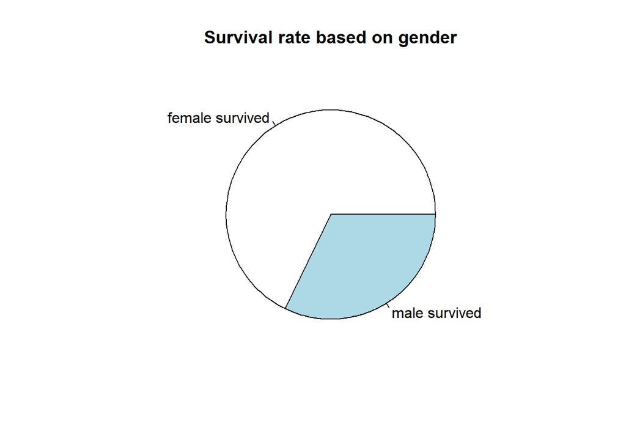

```r
#INSERT YOUR ANSWER HERE




totalSurvived=sum(survivedSex[2])

fSurvived=survivedSex[1, 2]
mSurvived=survivedSex[2, 2]
frate=fSurvived/totalSurvived
mrate=mSurvived/totalSurvived

slices <- c(frate, mrate)
lbls <- c("female survived", "male survived")
pie(slices, labels = lbls, main="Survival rate based on gender")



library(ggplot2)
```

```r
library(tidyverse)
```

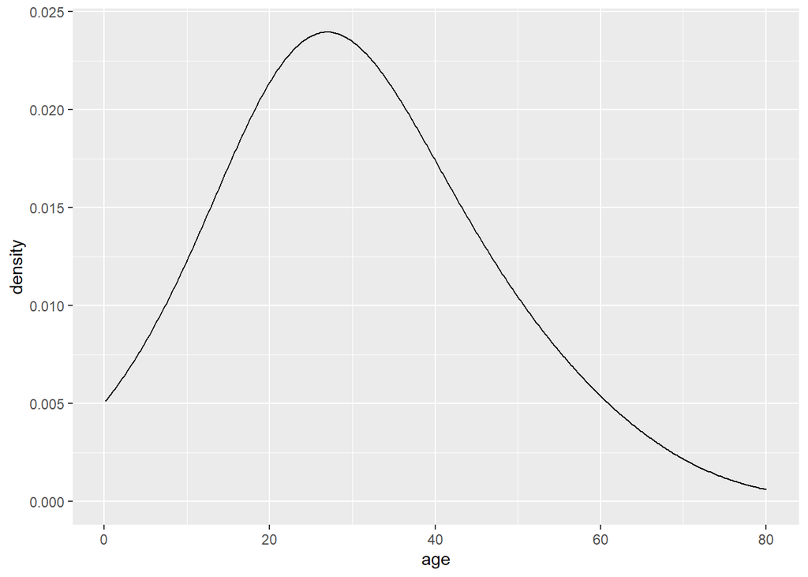

```r
titanicDataset %>%
filter(!is.na(age)) %>%
ggplot(aes(x = age, fill = age)) +
geom_density(alpha = 0.2, bw = 10)
```

e)Use the `for` loop and `if` control statements to list the women’s names, age 34 or more that emabrked from S (Southampton), on the Titanic.

```r
#INSERT YOUR ANSWER HERE

titanicDataset <- titanicDataset[! is.na(titanicDataset$age),]
titanicDataset <- titanicDataset[! is.na(titanicDataset$sex),]
titanicDataset <- titanicDataset[! is.na(titanicDataset$embarked),]


for(i in 1:nrow(titanicDataset)){
  if (titanicDataset$age[i] >=34 & titanicDataset$sex[i]=="female" & titanicDataset$embarked[i]=="S")
      {print(titanicDataset$name[i])}
}
```

```
## [1] "Andrews, Miss. Kornelia Theodosia"
## [1] "Appleton, Mrs. Edward Dale (Charlotte Lamson)"
## [1] "Beckwith, Mrs. Richard Leonard (Sallie Monypeny)"
## [1] "Bissette, Miss. Amelia"
## [1] "Bonnell, Miss. Elizabeth"
## [1] "Brown, Mrs. John Murray (Caroline Lane Lamson)"
## [1] "Carter, Mrs. William Ernest (Lucile Polk)"
## [1] "Cavendish, Mrs. Tyrell William (Julia Florence Siegel)"
## [1] "Chaffee, Mrs. Herbert Fuller (Carrie Constance Toogood)"
## [1] "Cornell, Mrs. Robert Clifford (Malvina Helen Lamson)"
## [1] "Crosby, Miss. Harriet R"
## [1] "Crosby, Mrs. Edward Gifford (Catherine Elizabeth Halstead)"
## [1] "Dodge, Mrs. Washington (Ruth Vidaver)"
## [1] "Fortune, Mrs. Mark (Mary McDougald)"
## [1] "Futrelle, Mrs. Jacques Heath (Lily May Peel)"
```

[output cut: 65 more lines]

## Question 2

A study was conducted on GRE test takers to evaluate the success conditions. The success rate is 25%. A sample of 30 test takers is selected for the study. Use the binomial distribution to calculate the followings:

1. The probability that 10 test takers fail the GRE test:

```r
#INSERT YOUR ANSWER HERE
dbinom(10,size = 30,prob = 0.75)
```

```
## [1] 1.538811e-06
```

2. The probability of getting at least five test takers succeed in the test

```r
#INSERT YOUR ANSWER HERE

1-pbinom(4,size = 30,prob =0.25)
```

```
## [1] 0.9021304
```

```r
#pbinom(4,size=30, prob = .25, lower.tail = F)
```

3. The probability of 25 or less fail the test

```r
#INSERT YOUR ANSWER HERE
pbinom(25, size = 30,prob = 0.75)
```

```
## [1] 0.9021304
```

## Question 3

In a shipment of 20 engines, history shows that the probability of any one engine proving unsatisfactory is 0.1

```r
#INSERT YOUR ANSWER HERE

pbinom(9,size = 20,prob = 0.1, lower.tail = F)
```

```
## [1] 7.150904e-06
```

```r
# 1-pbinom(9,size = 20,prob = 0.1)
```

2. Use the Poisson approximation to calculate the probability that at most three engines are defective?

```r
#INSERT YOUR ANSWER HERE

ppois(3,lambda =  20*0.1)
```

```
## [1] 0.8571235
```

```r
# ppois(3,2)
```

2. Use the binomial approximation to calculate the probability that at most three engines are defective?

```r
#INSERT YOUR ANSWER HERE

pbinom(3, size = 20, prob = 0.1)
```

```
## [1] 0.8670467
```

3. Compare the results of parts a and b, then illustrate on how well the Poisson probability distribution approximates the Binomial probability distribution.

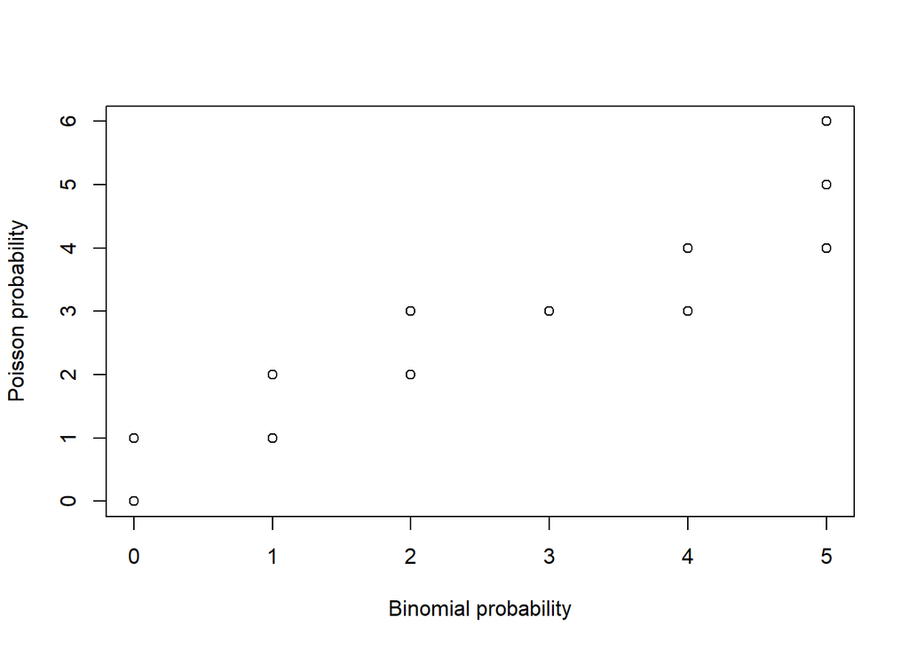

```r
#INSERT YOUR ANSWER HERE

binomsamp <-rbinom(50,size=20,prob=.1)
poissamp <- rpois(50,lambda = 2)
qqplot(binomsamp,poissamp, plot.it = TRUE, xlab = "Binomial probability", ylab ="Poisson probability")
```

## Question 4

Write a script in R to compute the following probabilities of a normal random variable with mean 16 and variance 9

1. lies between 14.4 and 20.3 (inclusive)

```r
#INSERT YOUR ANSWER HERE

pnorm(20.3, 16, sd=3)-pnorm(14.4, 16, sd=3)
```

```
## [1] 0.6272173
```

2. is greater than 21.8

```r
#INSERT YOUR ANSWER HERE

1-pnorm(21.8,16,sd=3)
```

```
## [1] 0.02659757
```

3. is less or equal to 10.5

```r
#INSERT YOUR ANSWER HERE

pnorm(10.5, 16, sd=3)
```

```
## [1] 0.03337651
```

4. is less than 13 or greater than 19

```r
#INSERT YOUR ANSWER HERE

pnorm(13, 16,sd=3) +1-pnorm(19, 16,sd=3)
```

```
## [1] 0.3173105
```

END of Assignment #2.